# Attributions for poverty in Post-Socialist Countries

Sixth Joint IOS/APB/EACES Summer Academy:  
*Poverty, Social Exclusion, and Income Inequality Dynamics in Central and Eastern Europe.*  
June 4 to 6, 2014

`Markus Kainu`  
*Researcher, [University of Turku](https://www.utu.fi/fi/yksikot/soc/yksikot/sosiaalitieteet/Sivut/home.aspx)* & *[Aleksanteri institute, University of Helsinki](http://helsinki.fi/aleksanteri), Finland*  
`Mikko Niemelä`  
*Research professor, [Social Insurance Institution](http://kela.fi), Finland*

Project page: http://bit.ly/tutzing14

[figure not shown]

### My research

> I’m a quantitatively orientated social scientist specialized in poverty and inequalities in post-socialist space, and in open source software carpentry

## Social policy research

- Ongoing PhD project: *Poverty, place and income redistribution - Analysis of poverty dynamics in post-socialist transition"*
- teacher in social policy at the department of social research in University of Turku, Finland
- researcher at the [Aleksanteri institute](http://www.helsinki.fi/aleksanteri/english/)

## Software carpentry

- [rOpenGov/](http://ropengov.github.io/) - *R Ecosystem for Open Government Data and Computational Social Science*
  - [Russian data](https://github.com/rOpenGov/rustfare)
  - [Eurostat](https://github.com/rOpenGov/eurostat)
  - [Quality of Government data](https://github.com/muuankarski/rqog)
  - [EU-SILC](https://github.com/muuankarski/r.eusilc)

### Purpose of the study

## 1. Cross-national differences

*To what extent there are cross-national differences in attributions for poverty in post-socialist countries?*

## 2. Determinants

*Can perceptions be attributed to certain contextual and individual level factors?*

1. Individual level: specific risks related to household financial circumstances
2. Contextual level: goodness of the government, human development and changes in national economy

### Welfare attitudes vs. welfare state policies

Causation between attitutes and policies is believed to exist in both directions:

1. Welfare attitudes constrain the decision making and institutional change by limiting the range of programs perceived acceptable
2. Type of welfare policy affects the welfare attitudes
   - in countries with more marginal and less generous welfare programmes, explanations of poverty are more often based on **individual morality**
   - in the Continental and Nordic welfare states **external and structural** explanations prevail

### Different types of explanations

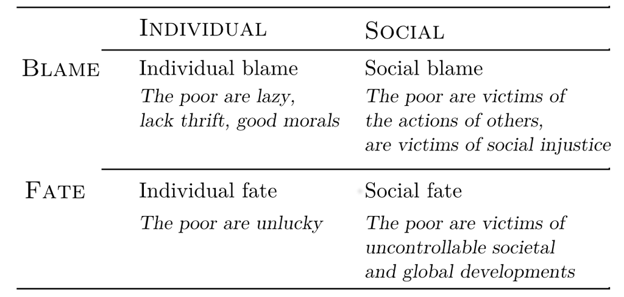

*Source: van Oorschot and Halman (2000)*

### Assumptions

## Cross-national differences

- Difference between post-socialist and West of Europe
- Large variation within post-socialist regime

## Individual level determinants:

- Self-interest approach: *to what extent risk factors related to financial hardship are associated with perceptions of the causes of poverty*

## Contextual level determinants:

- Differencies in socio-economic conditions and in governance
  1. economic performance during the period of global financial crises
  2. human development
  3. goodness of government

### Data

## Life in Transition Survey - 2nd round (LiTS2)

- collected in late 2010 in 34 countries and 39000 households
- assess public attitudes, well-being and the impacts of economic and political change at the household level
- special emphasis on how lives have been affected by the global economic crisis and its aftermath
- …with contextual level data from World Bank (derived from Quality of Government -data)

### 21 Post-Socialist and 5 Western European countries

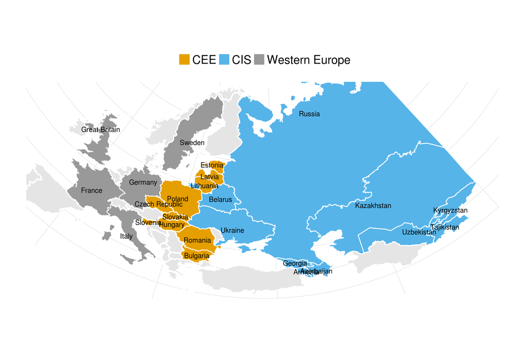

### Novelty of the study

- in depth study of “post-socialist welfare regime”
- wider variety of political and economical regimes
  - dynamics of welfare attitudes, welfare state and democracy in authoritarian regimes
- assessing the impact of past, present and future expectations
- comparing countries that have suffered from financial crisis and countries that have not

# Dependent variable

### Dependent variable

*In your opinion, what is the main reason why there are some people in need in our country today?* (Variable `q309` in LiTS-data)

- Because they have been unlucky
- Because of laziness and lack of willpower
- Because of injustice in our society
- It is an inevitable part of modern life
- Don't know
- Not stated

### Weighted population shares of DV by country

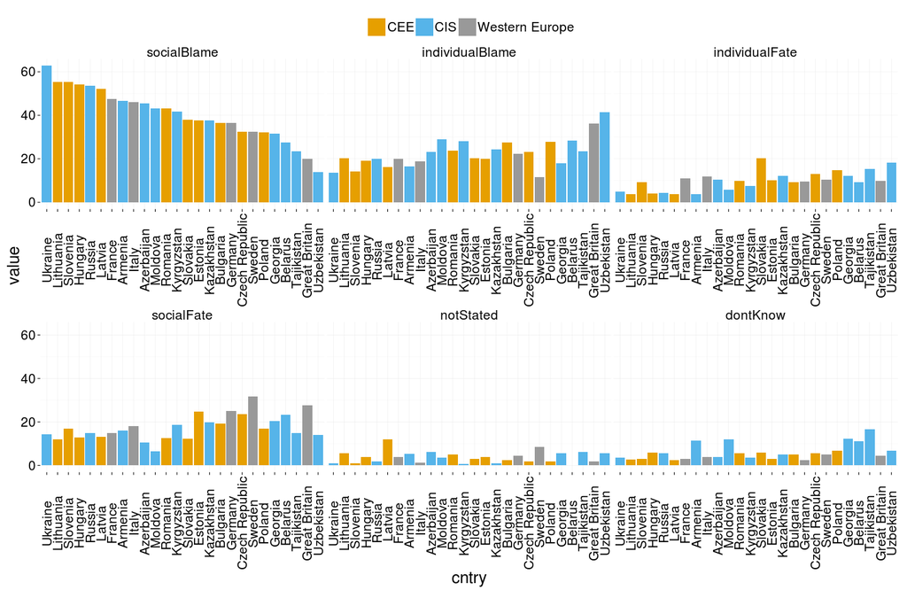

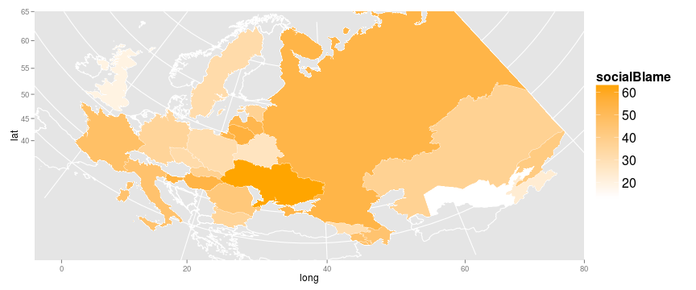

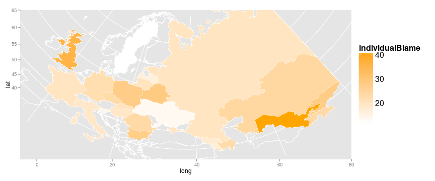

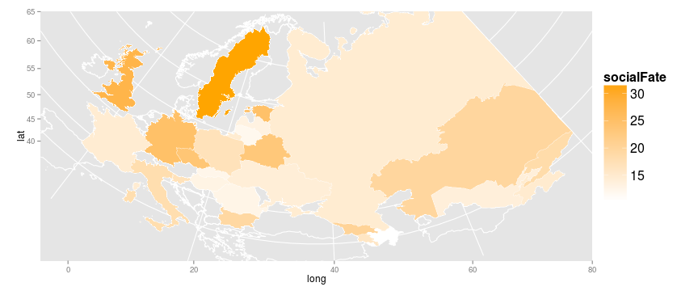

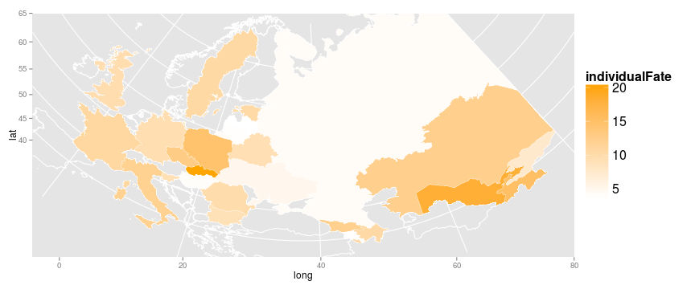

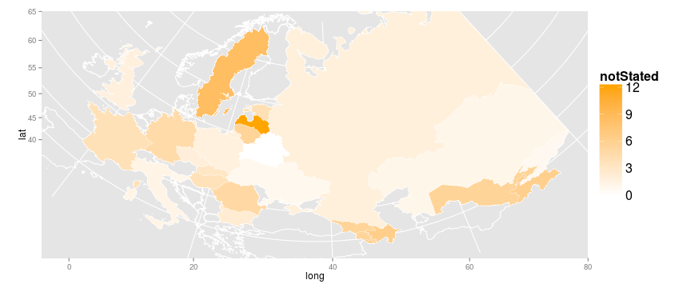

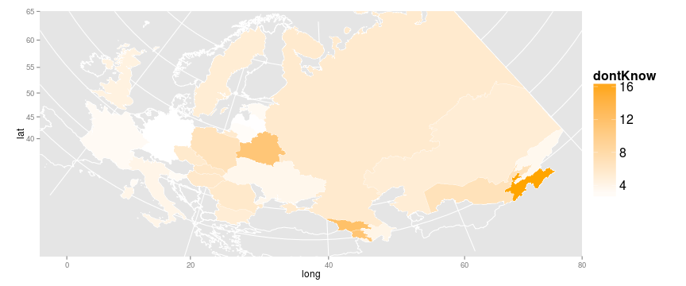

# Independent variables

## Individual level

### Individual level

| Variable | Description |
| --- | --- |
| Transfer dependency | Social or private transfers as main source of income |
| Low education | No or only compulsory level education |
| Perceived low income level | Perceived income level below the country median |
| Income compared to past | Perceived change in income compared to situation in four years ago |
| Income compared to future | Expected change in income over the next four years |
| Effect of financial crises | Whether respondents perceives that their household has suffered the financial crisis great or fair amount |

### Weighted population shares of IV (ind) by country

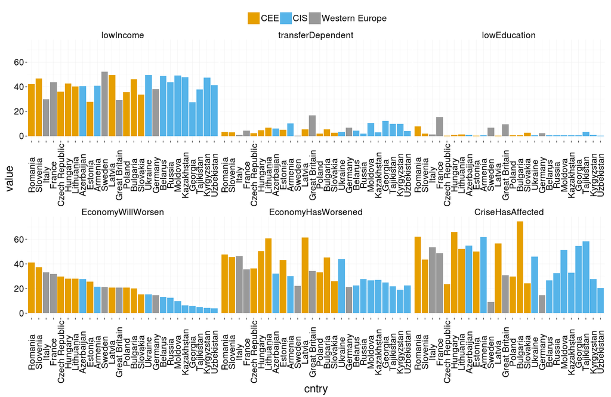

# Independent variables

## Contextual level

### Contextual level

| Variable | Description |
| --- | --- |
| Ghange in total GDP 2007 – 2010 | Relative change from 2007 to 2010 |
| Human Development Index | Indicator of human development/living conditions. Measures life expectancy, education, and income indices as a composite statistics |
| Voice and Accountability Description | Indicator of state of democracy. Measures the political process, civil liberties and political rights |

### Contextual level IV

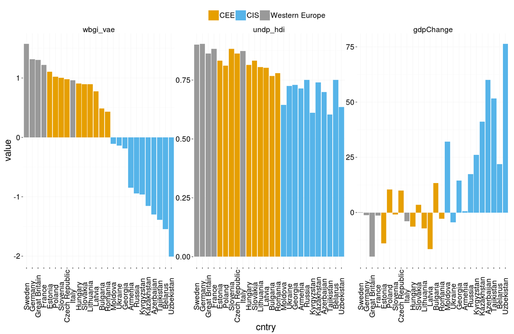

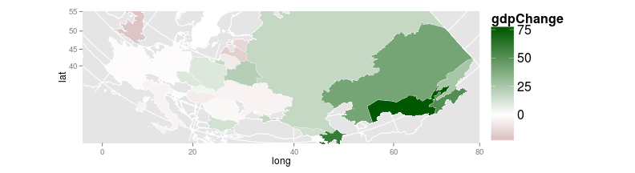

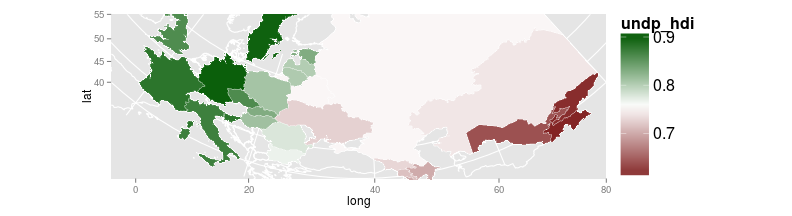

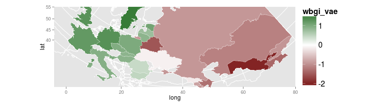

Change in total GDP in 2007 - 2010 and support for social blame type of attributions for poverty

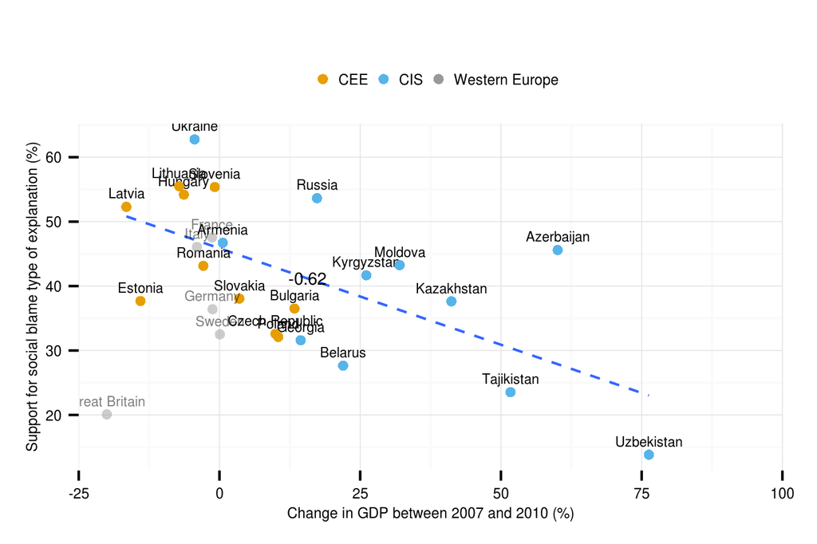

Change in total GDP in 2007 - 2010 and support for social individual blame type of attributions for poverty

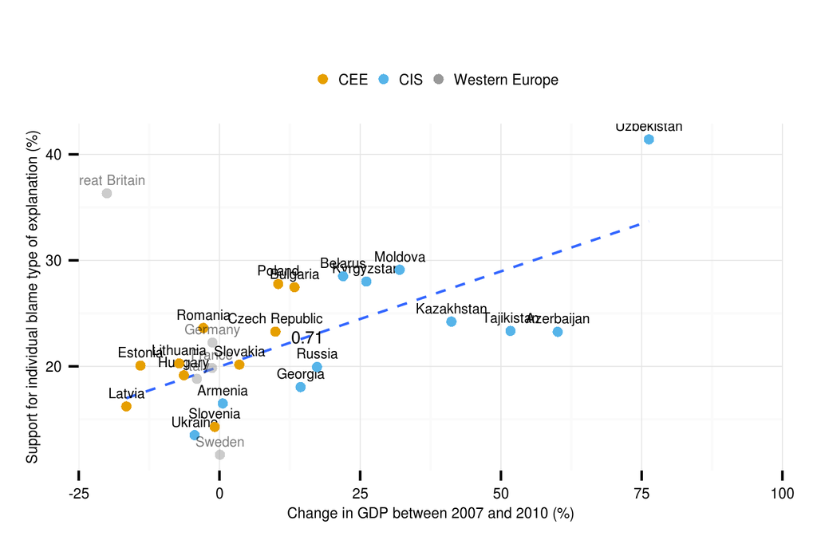

Human Development Index and support for social blame type of attributions for poverty

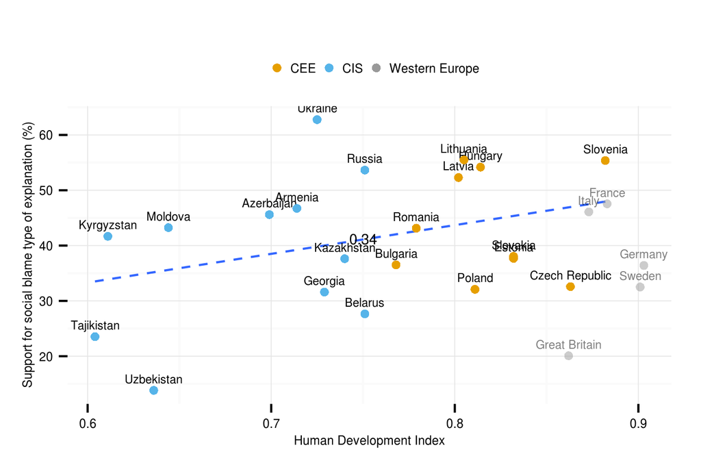

Human Development Index and support for social individual blame type of attributions for poverty

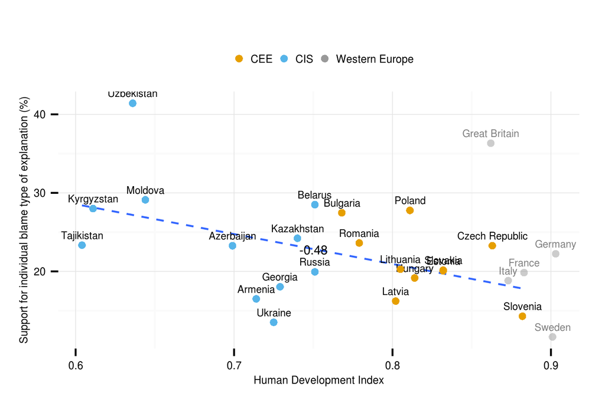

Voice and Accountability and support for social blame type of attributions for poverty

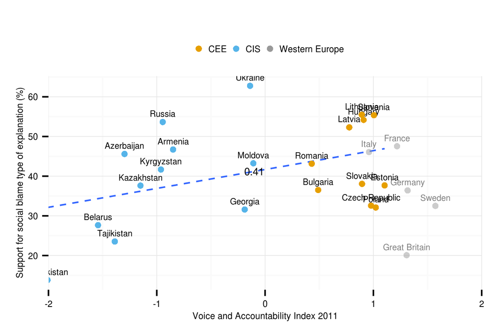

Voice and Accountability and support for social individual blame type of attributions for poverty

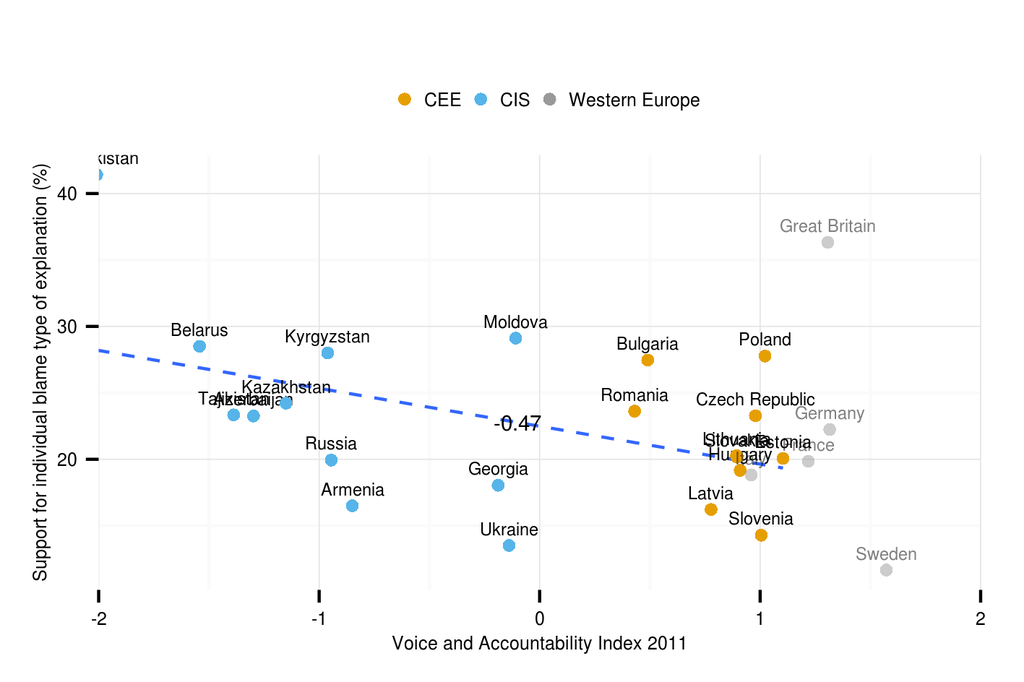

# Results of the modelling

### Regression modelling

## Constraints

- DV is categorical/factor with values: A,B,C,D
- Major differences in IV's by country
  - clustered data (individual within countries)
  - multilevel/mixed effects model setting

## Current solution

- As we are interested in two blame type of explanation
- Our current solution to recode variable into two binary variables
  - 1. A/not-A
  - 1. B/not-B and
- model the data using logistic binary multilevel models for A/not-A, B/not-B and A/B

Logistic multilevel random intercept model for social blame (SB) type of explanation

|  | **SB empty** | **SB individual** | **SB contextual** | **SB all** |
| --- | --- | --- | --- | --- |
| (intercept) | -0.39** | 0.36 | 0.38 | 0.88 |
|  | (0.12) | (0.21) | (1.51) | (1.48) |
| Dependent |  | -0.20** |  | -0.20** |
|  |  | (0.07) |  | (0.07) |
| Low education |  | 0.11 |  | 0.11 |
|  |  | (0.16) |  | (0.16) |
| Low income |  | -0.36*** |  | -0.37*** |
|  |  | (0.03) |  | (0.03) |
| Income has worsened |  | -0.06 |  | -0.06 |
|  |  | (0.04) |  | (0.04) |
| Income will worsen |  | -0.32*** |  | -0.32*** |
|  |  | (0.04) |  | (0.04) |
| Has affected great or fair amount |  | -0.32*** |  | -0.32*** |
|  |  | (0.04) |  | (0.04) |
| Human Deveplopment Index |  |  | -0.65 | -0.36 |
|  |  |  | (1.96) | (1.91) |
| Change in GDP between 2007 to 2010 |  |  | -0.02** | -0.02** |
|  |  |  | (0.01) | (0.01) |
| Voice and Accountability |  |  | -0.08 | -0.08 |
|  |  |  | (0.18) | (0.17) |
| AIC | 30343.40 | 21780.91 | 30337.63 | 21776.53 |
| BIC | 30359.53 | 21842.88 | 30377.96 | 21861.73 |
| Log Likelihood | -15169.70 | -10882.45 | -15163.82 | -10877.26 |
| Deviance | 30339.40 | 21764.91 | 30327.63 | 21754.53 |
| Num. obs. | 23513 | 17089 | 23513 | 17089 |
| Num. groups: cntry | 21 | 21 | 21 | 21 |
| Variance: cntry.(Intercept) | 0.29 | 0.26 | 0.16 | 0.15 |
| Variance: Residual | 1.00 | 1.00 | 1.00 | 1.00 |
| ***p < 0.001, **p < 0.01, *p < 0.05 |  |  |  |  |

Logistic multilevel random intercept model for individual blame (IB) type of explanation

|  | **IB empty** | **IB individual** | **IB contextual** | **IB all** |
| --- | --- | --- | --- | --- |
| (intercept) | -1.25*** | -2.19*** | -0.85 | -1.24 |
|  | (0.08) | (0.22) | (0.90) | (0.86) |
| Dependent |  | 0.37*** |  | 0.37*** |
|  |  | (0.09) |  | (0.09) |
| Low education |  | -0.04 |  | -0.04 |
|  |  | (0.18) |  | (0.18) |
| Low income |  | 0.28*** |  | 0.28*** |
|  |  | (0.04) |  | (0.04) |
| Income has worsened |  | 0.08 |  | 0.07 |
|  |  | (0.04) |  | (0.04) |
| Income will worsen |  | 0.27*** |  | 0.26*** |
|  |  | (0.05) |  | (0.05) |
| Has affected great or fair amount |  | 0.44*** |  | 0.44*** |
|  |  | (0.04) |  | (0.04) |
| Human Deveplopment Index |  |  | -0.77 | -1.45 |
|  |  |  | (1.17) | (1.09) |
| Change in GDP between 2007 to 2010 |  |  | 0.01*** | 0.01** |
|  |  |  | (0.00) | (0.00) |
| Voice and Accountability |  |  | 0.13 | 0.13 |
|  |  |  | (0.11) | (0.10) |
| AIC | 24900.01 | 18249.54 | 24891.15 | 18239.74 |
| BIC | 24916.15 | 18311.51 | 24931.47 | 18324.95 |
| Log Likelihood | -12448.01 | -9116.77 | -12440.57 | -9108.87 |
| Deviance | 24896.01 | 18233.54 | 24881.15 | 18217.74 |
| Num. obs. | 23513 | 17089 | 23513 | 17089 |
| Num. groups: cntry | 21 | 21 | 21 | 21 |
| Variance: cntry.(Intercept) | 0.12 | 0.10 | 0.05 | 0.04 |
| Variance: Residual | 1.00 | 1.00 | 1.00 | 1.00 |
| ***p < 0.001, **p < 0.01, *p < 0.05 |  |  |  |  |

Logistic multilevel random intercept model comparing the full models for both dependent variable with model predicting social blame against individual blame

|  | **SB vs. not** | **IB vs. not** | **SB vs. IB** |
| --- | --- | --- | --- |
| (intercept) | 0.88 | -1.24 | 1.61 |
|  | (1.48) | (0.86) | (1.34) |
| Dependent | -0.20** | 0.37*** | -0.43*** |
|  | (0.07) | (0.09) | (0.10) |
| Low education | 0.11 | -0.04 | -0.01 |
|  | (0.16) | (0.18) | (0.20) |
| Low income | -0.37*** | 0.28*** | -0.43*** |
|  | (0.03) | (0.04) | (0.04) |
| Income has worsened | -0.06 | 0.07 | -0.10* |
|  | (0.04) | (0.04) | (0.05) |
| Income will worsen | -0.32*** | 0.26*** | -0.41*** |
|  | (0.04) | (0.05) | (0.06) |
| Has affected great or fair amount | -0.32*** | 0.44*** | -0.53*** |
|  | (0.04) | (0.04) | (0.05) |
| Human Developmet Index | -0.36 | -1.45 | 0.73 |
|  | (1.91) | (1.09) | (1.72) |
| Change in GDP between 2007 to 2010 | -0.02** | 0.01** | -0.02*** |
|  | (0.01) | (0.00) | (0.01) |
| Voice and Accountability | -0.08 | 0.13 | -0.14 |
|  | (0.17) | (0.10) | (0.16) |
| AIC | 21776.53 | 18239.74 | 13565.27 |
| BIC | 21861.73 | 18324.95 | 13645.80 |
| Log Likelihood | -10877.26 | -9108.87 | -6771.63 |
| Deviance | 21754.53 | 18217.74 | 13543.27 |
| Num. obs. | 17089 | 17089 | 11169 |
| Num. groups: cntry | 21 | 21 | 21 |
| Variance: cntry.(Intercept) | 0.15 | 0.04 | 0.12 |
| Variance: Residual | 1.00 | 1.00 | 1.00 |
| ***p < 0.001, **p < 0.01, *p < 0.05 |  |  |  |

## contextual level predictors

- Change in total GDP 2007 – 2010

### Conclusions

## Cross-national differences

- highest support for social blame, followed by individual blame
- still, variation between countries relatively high

## Determinants

- contextual level: economic changes
- individual level: self-interest hypothesis supported

# Questions & comments

### How this presentation was done

## Analysis & presentation

&

## Platform

&

## Screencasting & Editing

&

## Publishing

&